# Cervical_Cancer_Risks_Part_Two slides

## Risk Factors for Cervical Cancer

## Summary of The Dataset

My goal was to see if there was any positive correlation between one or multiple risk factors (of those mentioned above) and a positive cervical cancer diagnosis. I have included information from previous studies to compare my results to and see if the information from this dataset lines up with current research findings.

## Data Research Information

- AGE: Fifty percent of cervical cancer diagnoses occur in women ages 35 - 54, and about 20% occur in women over 65 years of age. The median age of diagnosis is 48 years. About 15% of women develop cervical cancer between the ages of 20 - 30. Cervical cancer is extremely rare in women younger than age 20. However, many young women become infected with multiple types of human papilloma virus, which then can increase their risk of getting cervical cancer in the future. Young women with early abnormal changes who do not have regular examinations are at high risk for localized cancer by the time they are age 40, and for invasive cancer by age 50.

## Data Research Information Cont.

- USE OF ORAL CONTRACEPTIVES: Studies have reported a strong association between cervical cancer and long-term use of oral contraception (OC). Women who take birth control pills for more than 5 - 10 years appear to have a much higher risk HPV infection (up to four times higher) than those who do not use OCs. (Women taking OCs for fewer than 5 years do not have a significantly higher risk.) The reasons for this risk from OC use are not entirely clear. Women who use OCs may be less likely to use a diaphragm, condoms, or other methods that offer some protection against sexual transmitted diseases, including HPV. Some research also suggests that the hormones in OCs might help the virus enter the genetic material of cervical cells.

## Data Research Information Cont.

- HAVING MANY CHILDREN: Studies indicate that having many children increases the risk for developing cervical cancer, particularly in women infected with HPV.
- SMOKING: Smoking is associated with a higher risk for precancerous changes (dysplasia) in the cervix and for progression to invasive cervical cancer, especially for women infected with HPV.

  Research information obtained from [Kaggle Cervical Cancer Risks Classification](https://www.kaggle.com/loveall/cervical-cancer-risk-classification)

## Patients with Cervical Cancer Diagnosis

Of the 858 women included in this dataset, there are 18 women that have a positive diagnosis (yes) for cervical cancer and 840 that have a negative diagnosis (no). Considering there is such a small number of women represented with a positive cervical cancer diagnosis, I would expect to not always see the significant differences mentioned in the research information in regards to cervical cancer diagnosis and the observed risk factors. A larger dataset of patients would be recommended.

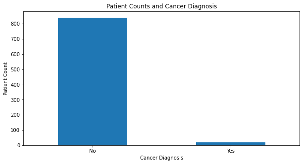

## Distribution of Ages

The ages of the women in my dataset range from 13 years old to 84 years old. The majority of the women in the dataset are 20-30 years old.

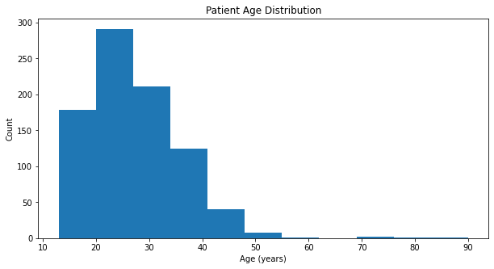

## Distribution of Women Who Are Smokers and How Long They Have Smoked

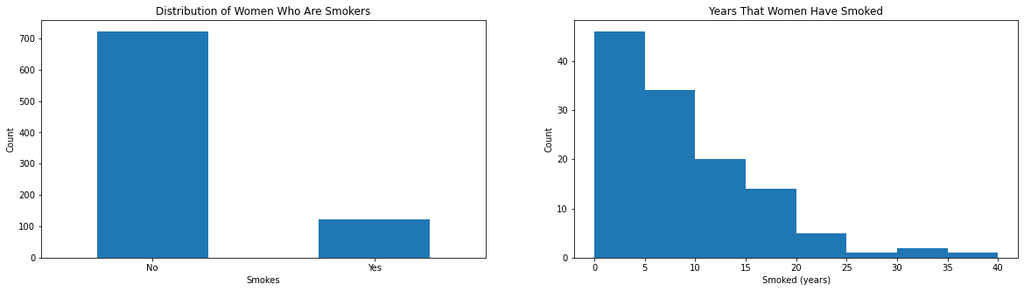

## Women and Hormonal Contraceptive Use

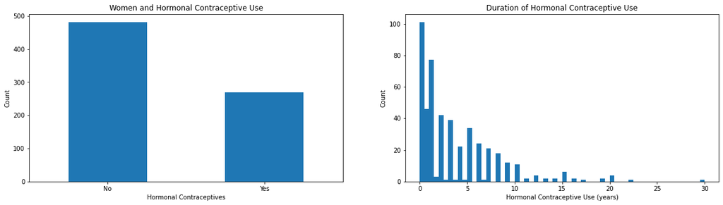

## Age vs. Cancer Diagnosis

The majority of positive cervical cancer diagnosises happen between ages 20-40 with a median age of approx. 33 years old. There are no positive cervical cancer diagnosies for ages above ~63 years old for this dataset.

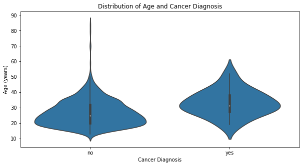

## Hormonal Contraceptive Use and Cancer

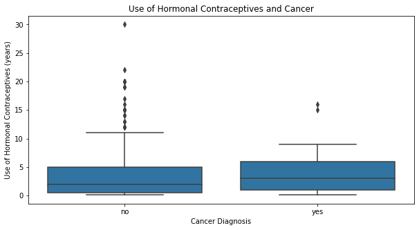

## Smoking and Cancer Diagnosis

Further exploration shows that there were only two people in the dataset that were smokers and had cervical cancer. It would be hard to say if there is a relationship between smoking and cervical cancer based on this dataset. As I investigated the information on the two individuals that had cancer, I could see that there was a lot of variation in their information. For example, the amount of packs they smoked in a year, age, number of pregnancies, etc. did not show a relation to each other. It is interesting to see that a large number of the women in this dataset are smokers and only two have cervical cancer. This is counterintuitive to what I was expecting to find. I feel that this dataset is too small for this particular questions and I feel that in order to get a better idea of if there is a relationship between smoking and cervical cancer I would need to look at a larger data set. Given this information I would consider this a dead end for investigation of the smoking risk factor with the given data.

|  | age | num_of_pregnancies | smokes | smokes_years | smokes_packs_per_year | hormonal_contraceptives | hormonal_contraceptives_years | Dx:Cancer | Dx:HPV |
| --- | --- | --- | --- | --- | --- | --- | --- | --- | --- |
| 3 | 52 | 4.0 | 1.0 | 37.0 | 37.00 | 1.0 | 3.0 | yes | 1 |
| 849 | 32 | 1.0 | 1.0 | 11.0 | 0.16 | 1.0 | 6.0 | yes | 1 |

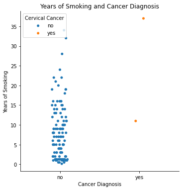

## Number of Pregnancies for Women with Cervical Cancer

[figure not shown]

## Age, Number of Pregnancies, and Cervical Cancer

In order to get a better picture of how the number of pregnancies may impact a woman's risk for cervical cancer, I explored how age may affect the relationship between number of pregnancies and cervical cancer. I wanted to see if number of pregnancies was simply an indicator of age or if the data showed a relationship regardless of age. The scatter plot below shows similar information to that which I found in the donut plot in regards to number of pregnancies and cervical cancer. You can see that at 0 pregnancies there are no positive cervical cancer diagnosises. However, it also shows very few negative diagnosises. We can see this trend continues regardless of age. This could mean that there is a relation to the number of preganancies and cervical cancer or it could mean that women that had never been preganant were not tested. This would makes sense as an HPV test is recommended when a woman is getting prenatal care. Finally, the data shows a positive correlation between age, number of pregnancies and cervical cancer between the ages of 19-53.

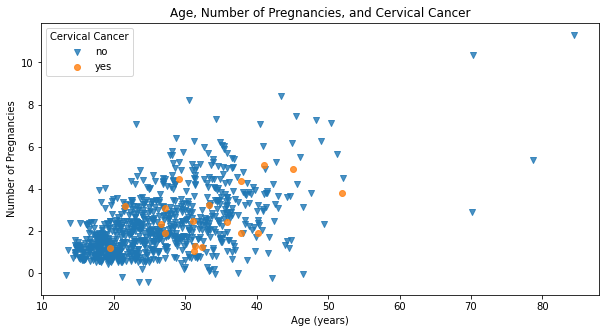

## Age, Hormonal Contraceptive Use, and Cancer Diagnosis

The relationship between longevity of hormonal contraceptive use, age, and cervical cancer appears to have a positive relationship. There seems to be a greater number of women that use hormonal contraceptives and are positive of cervical cancer between the ages of 27-37. It is hard to tell if the longevity of hormonal contraceptive use has a major effect on a women's risk for cervical cancer but the data does show that any use of hormonal contraceptives combined with age could increase a woman;s risk of cervical cancer.

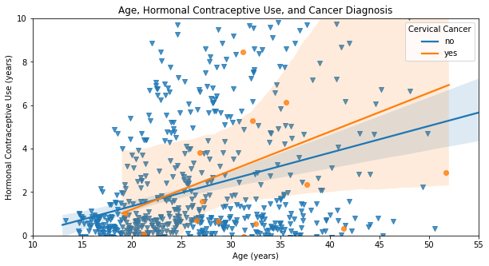

## Positive for Cervical Cancer, Age, and HPV Diagnosis

To prepare the visual, I filtered the data for women that were positive for cervical cancer and then grouped them by age. I compared their HPV diagnosises to see if there was an uneven distribution between those that had a positive HPV diagnosis and those that were negative. The results of the investigation show that a majority of the women from the dataset that were positive for cervical cancer were also positive for HPV.

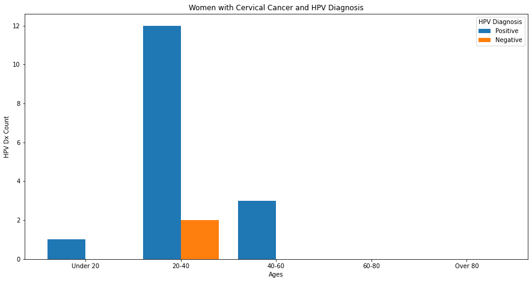

## Women with Cervical Cancer, Number of Pregnancies and HPV Diagnosis

In the beginning of this presentation there was information from research on a variety of risk factors for cervical cancer. The information said that a woman's risk for cervical cancer went up significantly if she had a positive HPV diagnosis and numerous pregnancies. I explored the dataset to see if this data told the same story. I used a catplot to show the relation of the three variables. I placed the cervical cancer diagnosis on the x-axis and the number of pregnancies on the y-axis. I then added a hue to signifiy if a woman was HPV positive (yes) or negative (no). I found that of the women that were positive for cervical cancer, all of them had at least one pregnancy and most were HPV positive. All women who had more than one pregnancy and HPV positive had a positive cervical cancer diagnosis.

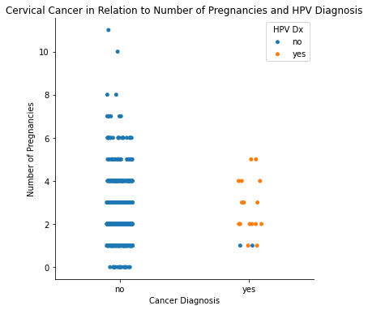